# How to reorder audio frames?

We take an audio and generate frames of 93 ms length with a step of 23 ms. Then we ask. What criteria should we use to reorder the frames?

Random sounds like this.

```
Original
```

[interactive chart not shown]

```
Randomized
```

[interactive chart not shown]

Next attempt will consider generating a ordering based on this sound descriptors, RMS, Pitch, Chromagram, MFCC, Spectral Contrast, and Mel spectrogram. We will sort the frames following the principal components of the merged descriptors. This is, we perform a sorting that goes with the first PC, then the second, and so on.

```
Order by descriptros PCs
```

[interactive chart not shown]

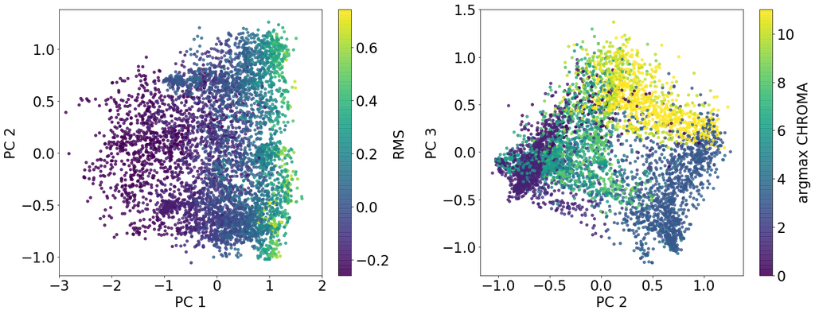

The result has an overall intensity crescendo (PC 1) and local chroma transitions (PC 2, 3). To further analyze the content of the PC ordering we could generate an sound impression by a sliding projection over one direction and hearing an average sound from all other directions.

```
Moving on PC 0
```

[interactive chart not shown]

```
Moving on PC 1
```

[interactive chart not shown]

```
Moving on PC 2
```

[interactive chart not shown]

```
Moving on PC 3
```

[interactive chart not shown]

Let continue with these short duration expositions. Now a 30 second pitch reordering.

[output not shown]

[interactive chart not shown]

# Walking the graph of sound similarities

In most of the sound excerpts heard so far there is a continuous trembling because the sound descriptors are noisy. To overcome those fluctuations we want that consecutive frames sound as much a like as possible. From another perspective, we want a path over the complete graph of fragments that minimize the dissimilarities. This is the traveling salesman problem. We compute the sound dissimilarities as the euclidean distance of the merged descriptors.